# Risk Factor Analysis

## Outcome Variable

**Outcome Variable:** stunted

## Predictor Variables

**Intervention Variable:** nrooms

**Adjustment Set:**

- arm
- sex
- W_mage
- meducyrs
- feducyrs
- hhwealth_quart
- hfoodsec
- W_mhtcm
- W_nchldlt5
- W_parity
- impfloor
- impsan
- safeh20
- delta_W_mage
- delta_meducyrs
- delta_feducyrs
- delta_hhwealth_quart
- delta_hfoodsec
- delta_W_mhtcm
- delta_W_nchldlt5
- delta_W_parity
- delta_impfloor
- delta_impsan
- delta_safeh20

## Stratifying Variables

The analysis was stratified on these variable(s):

- agecat
- studyid
- country

## Data Summary

| agecat | studyid | country | nrooms | stunted | n_cell | n |
| --- | --- | --- | --- | --- | --- | --- |
| Birth | ki0047075b-MAL-ED | BANGLADESH | 1 | 0 | 116 | 234 |
| Birth | ki0047075b-MAL-ED | BANGLADESH | 1 | 1 | 28 | 234 |
| Birth | ki0047075b-MAL-ED | BANGLADESH | 2 | 0 | 42 | 234 |
| Birth | ki0047075b-MAL-ED | BANGLADESH | 2 | 1 | 8 | 234 |
| Birth | ki0047075b-MAL-ED | BANGLADESH | 3 | 0 | 26 | 234 |
| Birth | ki0047075b-MAL-ED | BANGLADESH | 3 | 1 | 2 | 234 |
| Birth | ki0047075b-MAL-ED | BANGLADESH | 4+ | 0 | 12 | 234 |
| Birth | ki0047075b-MAL-ED | BANGLADESH | 4+ | 1 | 0 | 234 |
| 6 months | ki0047075b-MAL-ED | BANGLADESH | 1 | 0 | 120 | 240 |
| 6 months | ki0047075b-MAL-ED | BANGLADESH | 1 | 1 | 30 | 240 |
| 6 months | ki0047075b-MAL-ED | BANGLADESH | 2 | 0 | 40 | 240 |
| 6 months | ki0047075b-MAL-ED | BANGLADESH | 2 | 1 | 10 | 240 |
| 6 months | ki0047075b-MAL-ED | BANGLADESH | 3 | 0 | 24 | 240 |
| 6 months | ki0047075b-MAL-ED | BANGLADESH | 3 | 1 | 4 | 240 |
| 6 months | ki0047075b-MAL-ED | BANGLADESH | 4+ | 0 | 11 | 240 |
| 6 months | ki0047075b-MAL-ED | BANGLADESH | 4+ | 1 | 1 | 240 |
| 24 months | ki0047075b-MAL-ED | BANGLADESH | 1 | 0 | 70 | 212 |
| 24 months | ki0047075b-MAL-ED | BANGLADESH | 1 | 1 | 64 | 212 |
| 24 months | ki0047075b-MAL-ED | BANGLADESH | 2 | 0 | 21 | 212 |
| 24 months | ki0047075b-MAL-ED | BANGLADESH | 2 | 1 | 19 | 212 |
| 24 months | ki0047075b-MAL-ED | BANGLADESH | 3 | 0 | 16 | 212 |
| 24 months | ki0047075b-MAL-ED | BANGLADESH | 3 | 1 | 11 | 212 |
| 24 months | ki0047075b-MAL-ED | BANGLADESH | 4+ | 0 | 7 | 212 |
| 24 months | ki0047075b-MAL-ED | BANGLADESH | 4+ | 1 | 4 | 212 |
| Birth | ki0047075b-MAL-ED | BRAZIL | 1 | 0 | 3 | 174 |
| Birth | ki0047075b-MAL-ED | BRAZIL | 1 | 1 | 0 | 174 |
| Birth | ki0047075b-MAL-ED | BRAZIL | 2 | 0 | 18 | 174 |
| Birth | ki0047075b-MAL-ED | BRAZIL | 2 | 1 | 1 | 174 |
| Birth | ki0047075b-MAL-ED | BRAZIL | 3 | 0 | 43 | 174 |
| Birth | ki0047075b-MAL-ED | BRAZIL | 3 | 1 | 7 | 174 |

[output cut: 328 more lines]

The following strata were considered:

- agecat: 24 months, studyid: ki0047075b-MAL-ED, country: BANGLADESH
- agecat: 24 months, studyid: ki0047075b-MAL-ED, country: BRAZIL
- agecat: 24 months, studyid: ki0047075b-MAL-ED, country: INDIA
- agecat: 24 months, studyid: ki0047075b-MAL-ED, country: NEPAL
- agecat: 24 months, studyid: ki0047075b-MAL-ED, country: PERU
- agecat: 24 months, studyid: ki0047075b-MAL-ED, country: SOUTH AFRICA
- agecat: 24 months, studyid: ki0047075b-MAL-ED, country: TANZANIA, UNITED REPUBLIC OF
- agecat: 24 months, studyid: ki1000108-CMC-V-BCS-2002, country: INDIA
- agecat: 24 months, studyid: ki1000108-IRC, country: INDIA
- agecat: 24 months, studyid: ki1017093b-PROVIDE, country: BANGLADESH
- agecat: 24 months, studyid: ki1017093c-NIH-Crypto, country: BANGLADESH
- agecat: 24 months, studyid: ki1113344-GMS-Nepal, country: NEPAL
- agecat: 24 months, studyid: ki1114097-CONTENT, country: PERU
- agecat: 24 months, studyid: ki1135781-COHORTS, country: INDIA
- agecat: 24 months, studyid: kiGH5241-JiVitA-3, country: BANGLADESH
- agecat: 24 months, studyid: kiGH5241-JiVitA-4, country: BANGLADESH
- agecat: 6 months, studyid: ki0047075b-MAL-ED, country: BANGLADESH
- agecat: 6 months, studyid: ki0047075b-MAL-ED, country: BRAZIL
- agecat: 6 months, studyid: ki0047075b-MAL-ED, country: INDIA
- agecat: 6 months, studyid: ki0047075b-MAL-ED, country: NEPAL
- agecat: 6 months, studyid: ki0047075b-MAL-ED, country: PERU
- agecat: 6 months, studyid: ki0047075b-MAL-ED, country: SOUTH AFRICA
- agecat: 6 months, studyid: ki0047075b-MAL-ED, country: TANZANIA, UNITED REPUBLIC OF
- agecat: 6 months, studyid: ki1000108-CMC-V-BCS-2002, country: INDIA
- agecat: 6 months, studyid: ki1000108-IRC, country: INDIA
- agecat: 6 months, studyid: ki1017093b-PROVIDE, country: BANGLADESH
- agecat: 6 months, studyid: ki1017093c-NIH-Crypto, country: BANGLADESH
- agecat: 6 months, studyid: ki1113344-GMS-Nepal, country: NEPAL
- agecat: 6 months, studyid: ki1114097-CONTENT, country: PERU
- agecat: 6 months, studyid: ki1135781-COHORTS, country: INDIA
- agecat: 6 months, studyid: kiGH5241-JiVitA-3, country: BANGLADESH
- agecat: 6 months, studyid: kiGH5241-JiVitA-4, country: BANGLADESH
- agecat: Birth, studyid: ki0047075b-MAL-ED, country: BANGLADESH
- agecat: Birth, studyid: ki0047075b-MAL-ED, country: BRAZIL
- agecat: Birth, studyid: ki0047075b-MAL-ED, country: INDIA
- agecat: Birth, studyid: ki0047075b-MAL-ED, country: NEPAL
- agecat: Birth, studyid: ki0047075b-MAL-ED, country: PERU
- agecat: Birth, studyid: ki0047075b-MAL-ED, country: SOUTH AFRICA
- agecat: Birth, studyid: ki0047075b-MAL-ED, country: TANZANIA, UNITED REPUBLIC OF
- agecat: Birth, studyid: ki1000108-CMC-V-BCS-2002, country: INDIA
- agecat: Birth, studyid: ki1000108-IRC, country: INDIA
- agecat: Birth, studyid: ki1017093c-NIH-Crypto, country: BANGLADESH
- agecat: Birth, studyid: ki1114097-CONTENT, country: PERU
- agecat: Birth, studyid: ki1135781-COHORTS, country: INDIA
- agecat: Birth, studyid: kiGH5241-JiVitA-3, country: BANGLADESH
- agecat: Birth, studyid: kiGH5241-JiVitA-4, country: BANGLADESH

### Dropped Strata

Some strata were dropped due to rare outcomes:

- agecat: Birth, studyid: ki0047075b-MAL-ED, country: BANGLADESH
- agecat: 6 months, studyid: ki0047075b-MAL-ED, country: BANGLADESH
- agecat: 24 months, studyid: ki0047075b-MAL-ED, country: BANGLADESH
- agecat: Birth, studyid: ki0047075b-MAL-ED, country: BRAZIL
- agecat: 6 months, studyid: ki0047075b-MAL-ED, country: BRAZIL
- agecat: 24 months, studyid: ki0047075b-MAL-ED, country: BRAZIL
- agecat: Birth, studyid: ki0047075b-MAL-ED, country: INDIA
- agecat: 6 months, studyid: ki0047075b-MAL-ED, country: INDIA
- agecat: 6 months, studyid: ki0047075b-MAL-ED, country: NEPAL
- agecat: Birth, studyid: ki0047075b-MAL-ED, country: NEPAL
- agecat: Birth, studyid: ki0047075b-MAL-ED, country: PERU
- agecat: Birth, studyid: ki0047075b-MAL-ED, country: SOUTH AFRICA
- agecat: 6 months, studyid: ki0047075b-MAL-ED, country: SOUTH AFRICA
- agecat: Birth, studyid: ki0047075b-MAL-ED, country: TANZANIA, UNITED REPUBLIC OF
- agecat: 6 months, studyid: ki0047075b-MAL-ED, country: TANZANIA, UNITED REPUBLIC OF
- agecat: 24 months, studyid: ki0047075b-MAL-ED, country: TANZANIA, UNITED REPUBLIC OF
- agecat: 6 months, studyid: ki1000108-CMC-V-BCS-2002, country: INDIA
- agecat: Birth, studyid: ki1000108-CMC-V-BCS-2002, country: INDIA
- agecat: 6 months, studyid: ki1000108-IRC, country: INDIA
- agecat: Birth, studyid: ki1000108-IRC, country: INDIA
- agecat: 6 months, studyid: ki1017093b-PROVIDE, country: BANGLADESH
- agecat: Birth, studyid: ki1017093c-NIH-Crypto, country: BANGLADESH
- agecat: 6 months, studyid: ki1114097-CONTENT, country: PERU
- agecat: 24 months, studyid: ki1114097-CONTENT, country: PERU
- agecat: Birth, studyid: ki1114097-CONTENT, country: PERU

## Methods Detail

We’re interested in the causal parameters $E[Y_a]$ for all values of $a \in \mathcal{A}$. These parameters represent the mean outcome if, possibly contrary to fact, we intervened to set all units to have $A=a$. Under the randomization and positivity assumptions, these are identified by the statistical parameters $\psi_a=E_W[E_{Y|A,W}(Y|A=a,W)]$. In addition, we’re interested in the mean of $Y$, $E[Y]$ under no intervention (the observed mean). We will estimate these parameters by using SuperLearner to fit the relevant likelihood factors – $E_{Y|A,W}(Y|A=a,W)$ and $p(A=a|W)$, and then updating our likelihood fit using a joint TMLE.

For unadjusted analyses ($W=\{\}$), initial likelihoods were estimated using Lrnr_glm to estimate the simple $E(Y|A)$ and Lrnr_mean to estimate $p(A)$. For adjusted analyses, a small library containing Lrnr_glmnet, Lrnr_xgboost, and Lrnr_mean was used.

Having estimated these parameters, we will then use the delta method to estimate relative risks and attributable risks relative to a prespecified baseline level of $A$.

# Results Detail

## Results Plots

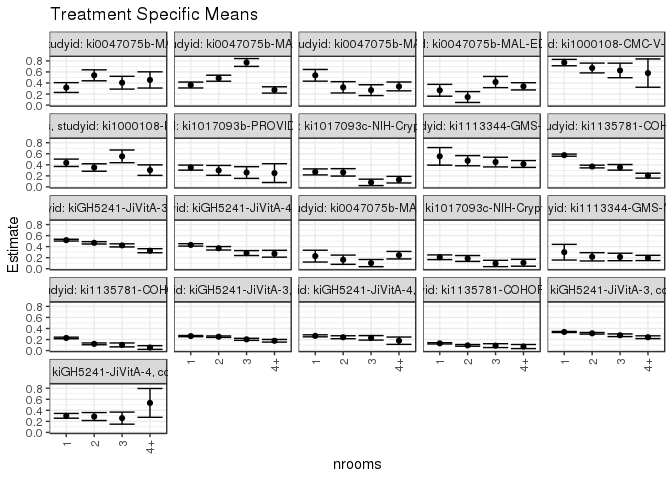

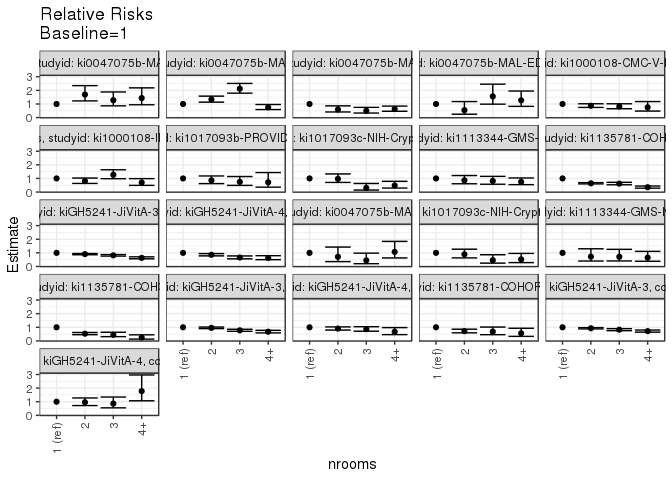

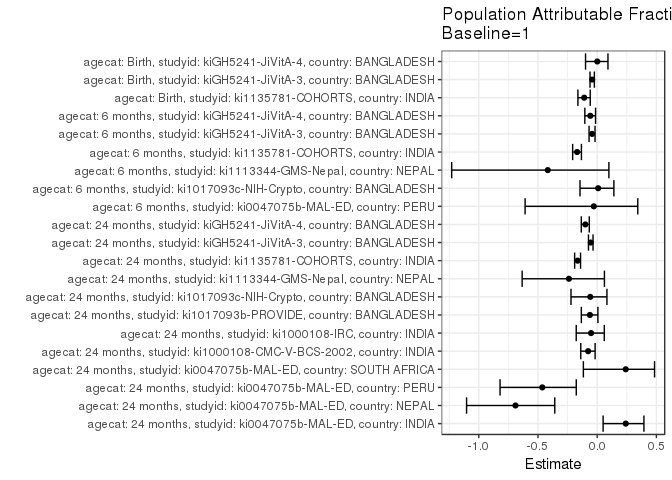

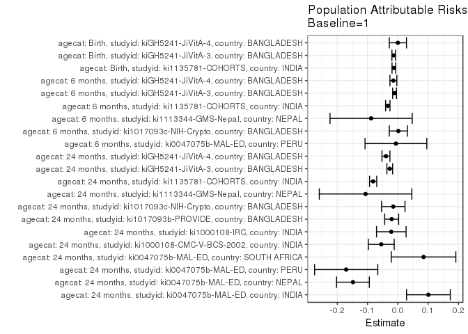

## Results Table

### Parameter: TSM

| agecat | studyid | country | intervention_level | baseline_level | estimate | ci_lower | ci_upper |
| --- | --- | --- | --- | --- | --- | --- | --- |
| Birth | ki1135781-COHORTS | INDIA | 1 | NA | 0.1314591 | 0.1199696 | 0.1429486 |
| Birth | ki1135781-COHORTS | INDIA | 2 | NA | 0.0939342 | 0.0785857 | 0.1092826 |
| Birth | ki1135781-COHORTS | INDIA | 3 | NA | 0.0894601 | 0.0543858 | 0.1245344 |
| Birth | ki1135781-COHORTS | INDIA | 4+ | NA | 0.0731083 | 0.0362564 | 0.1099603 |
| Birth | kiGH5241-JiVitA-3 | BANGLADESH | 1 | NA | 0.3369711 | 0.3276042 | 0.3463379 |
| Birth | kiGH5241-JiVitA-3 | BANGLADESH | 2 | NA | 0.3125737 | 0.2983597 | 0.3267878 |
| Birth | kiGH5241-JiVitA-3 | BANGLADESH | 3 | NA | 0.2773447 | 0.2532303 | 0.3014592 |
| Birth | kiGH5241-JiVitA-3 | BANGLADESH | 4+ | NA | 0.2417713 | 0.2167659 | 0.2667768 |
| Birth | kiGH5241-JiVitA-4 | BANGLADESH | 1 | NA | 0.3002491 | 0.2571669 | 0.3433312 |
| Birth | kiGH5241-JiVitA-4 | BANGLADESH | 2 | NA | 0.2871455 | 0.2149430 | 0.3593481 |
| Birth | kiGH5241-JiVitA-4 | BANGLADESH | 3 | NA | 0.2586117 | 0.1491913 | 0.3680321 |
| Birth | kiGH5241-JiVitA-4 | BANGLADESH | 4+ | NA | 0.5340239 | 0.2734395 | 0.7946082 |
| 6 months | ki0047075b-MAL-ED | PERU | 1 | NA | 0.2285025 | 0.1216356 | 0.3353695 |
| 6 months | ki0047075b-MAL-ED | PERU | 2 | NA | 0.1632689 | 0.0796331 | 0.2469047 |
| 6 months | ki0047075b-MAL-ED | PERU | 3 | NA | 0.1022672 | 0.0374523 | 0.1670820 |
| 6 months | ki0047075b-MAL-ED | PERU | 4+ | NA | 0.2455622 | 0.1776405 | 0.3134840 |
| 6 months | ki1017093c-NIH-Crypto | BANGLADESH | 1 | NA | 0.2080708 | 0.1654016 | 0.2507400 |
| 6 months | ki1017093c-NIH-Crypto | BANGLADESH | 2 | NA | 0.1859206 | 0.1328728 | 0.2389684 |
| 6 months | ki1017093c-NIH-Crypto | BANGLADESH | 3 | NA | 0.0955801 | 0.0385953 | 0.1525648 |
| 6 months | ki1017093c-NIH-Crypto | BANGLADESH | 4+ | NA | 0.1083594 | 0.0462448 | 0.1704740 |
| 6 months | ki1113344-GMS-Nepal | NEPAL | 1 | NA | 0.2995625 | 0.1575090 | 0.4416159 |
| 6 months | ki1113344-GMS-Nepal | NEPAL | 2 | NA | 0.2157694 | 0.1404550 | 0.2910839 |
| 6 months | ki1113344-GMS-Nepal | NEPAL | 3 | NA | 0.2132350 | 0.1457769 | 0.2806930 |
| 6 months | ki1113344-GMS-Nepal | NEPAL | 4+ | NA | 0.1951754 | 0.1477019 | 0.2426488 |
| 6 months | ki1135781-COHORTS | INDIA | 1 | NA | 0.2286395 | 0.2145962 | 0.2426827 |
| 6 months | ki1135781-COHORTS | INDIA | 2 | NA | 0.1214580 | 0.1050719 | 0.1378441 |
| 6 months | ki1135781-COHORTS | INDIA | 3 | NA | 0.1022489 | 0.0669743 | 0.1375235 |
| 6 months | ki1135781-COHORTS | INDIA | 4+ | NA | 0.0553130 | 0.0218628 | 0.0887633 |
| 6 months | kiGH5241-JiVitA-3 | BANGLADESH | 1 | NA | 0.2622688 | 0.2519879 | 0.2725496 |
| 6 months | kiGH5241-JiVitA-3 | BANGLADESH | 2 | NA | 0.2509820 | 0.2381220 | 0.2638420 |

[output cut: 54 more lines]

### Parameter: E(Y)

| agecat | studyid | country | intervention_level | baseline_level | estimate | ci_lower | ci_upper |
| --- | --- | --- | --- | --- | --- | --- | --- |
| Birth | ki1135781-COHORTS | INDIA | NA | NA | 0.1184735 | 0.1093005 | 0.1276464 |
| Birth | kiGH5241-JiVitA-3 | BANGLADESH | NA | NA | 0.3233958 | 0.3157274 | 0.3310641 |
| Birth | kiGH5241-JiVitA-4 | BANGLADESH | NA | NA | 0.3004866 | 0.2649179 | 0.3360553 |
| 6 months | ki0047075b-MAL-ED | PERU | NA | NA | 0.2222222 | 0.1725409 | 0.2719036 |
| 6 months | ki1017093c-NIH-Crypto | BANGLADESH | NA | NA | 0.2097902 | 0.1799252 | 0.2396552 |
| 6 months | ki1113344-GMS-Nepal | NEPAL | NA | NA | 0.2113677 | 0.1776128 | 0.2451225 |
| 6 months | ki1135781-COHORTS | INDIA | NA | NA | 0.1954857 | 0.1844503 | 0.2065211 |
| 6 months | kiGH5241-JiVitA-3 | BANGLADESH | NA | NA | 0.2514286 | 0.2432985 | 0.2595587 |
| 6 months | kiGH5241-JiVitA-4 | BANGLADESH | NA | NA | 0.2522280 | 0.2381653 | 0.2662906 |
| 24 months | ki0047075b-MAL-ED | INDIA | NA | NA | 0.4185022 | 0.3541865 | 0.4828179 |
| 24 months | ki0047075b-MAL-ED | NEPAL | NA | NA | 0.2149123 | 0.1614774 | 0.2683472 |
| 24 months | ki0047075b-MAL-ED | PERU | NA | NA | 0.3681592 | 0.3013164 | 0.4350020 |
| 24 months | ki0047075b-MAL-ED | SOUTH AFRICA | NA | NA | 0.3529412 | 0.2921001 | 0.4137823 |
| 24 months | ki1000108-CMC-V-BCS-2002 | INDIA | NA | NA | 0.7150538 | 0.6691221 | 0.7609854 |
| 24 months | ki1000108-IRC | INDIA | NA | NA | 0.4152334 | 0.3673018 | 0.4631651 |
| 24 months | ki1017093b-PROVIDE | BANGLADESH | NA | NA | 0.3292894 | 0.2909105 | 0.3676684 |
| 24 months | ki1017093c-NIH-Crypto | BANGLADESH | NA | NA | 0.2568093 | 0.2190047 | 0.2946140 |
| 24 months | ki1113344-GMS-Nepal | NEPAL | NA | NA | 0.4468938 | 0.4032281 | 0.4905594 |
| 24 months | ki1135781-COHORTS | INDIA | NA | NA | 0.4934649 | 0.4774590 | 0.5094709 |
| 24 months | kiGH5241-JiVitA-3 | BANGLADESH | NA | NA | 0.4908353 | 0.4776984 | 0.5039721 |
| 24 months | kiGH5241-JiVitA-4 | BANGLADESH | NA | NA | 0.3922477 | 0.3752571 | 0.4092384 |

### Parameter: RR

| agecat | studyid | country | intervention_level | baseline_level | estimate | ci_lower | ci_upper |
| --- | --- | --- | --- | --- | --- | --- | --- |
| Birth | ki1135781-COHORTS | INDIA | 1 | 1 | 1.0000000 | 1.0000000 | 1.0000000 |
| Birth | ki1135781-COHORTS | INDIA | 2 | 1 | 0.7145505 | 0.5938388 | 0.8597996 |
| Birth | ki1135781-COHORTS | INDIA | 3 | 1 | 0.6805166 | 0.4554559 | 1.0167898 |
| Birth | ki1135781-COHORTS | INDIA | 4+ | 1 | 0.5561299 | 0.3334472 | 0.9275245 |
| Birth | kiGH5241-JiVitA-3 | BANGLADESH | 1 | 1 | 1.0000000 | 1.0000000 | 1.0000000 |
| Birth | kiGH5241-JiVitA-3 | BANGLADESH | 2 | 1 | 0.9275982 | 0.8818548 | 0.9757143 |
| Birth | kiGH5241-JiVitA-3 | BANGLADESH | 3 | 1 | 0.8230521 | 0.7512621 | 0.9017024 |
| Birth | kiGH5241-JiVitA-3 | BANGLADESH | 4+ | 1 | 0.7174840 | 0.6438089 | 0.7995901 |
| Birth | kiGH5241-JiVitA-4 | BANGLADESH | 1 | 1 | 1.0000000 | 1.0000000 | 1.0000000 |
| Birth | kiGH5241-JiVitA-4 | BANGLADESH | 2 | 1 | 0.9563578 | 0.7171050 | 1.2754341 |
| Birth | kiGH5241-JiVitA-4 | BANGLADESH | 3 | 1 | 0.8613240 | 0.5522609 | 1.3433490 |
| Birth | kiGH5241-JiVitA-4 | BANGLADESH | 4+ | 1 | 1.7786030 | 1.0666706 | 2.9657032 |
| 6 months | ki0047075b-MAL-ED | PERU | 1 | 1 | 1.0000000 | 1.0000000 | 1.0000000 |
| 6 months | ki0047075b-MAL-ED | PERU | 2 | 1 | 0.7145169 | 0.3581526 | 1.4254662 |
| 6 months | ki0047075b-MAL-ED | PERU | 3 | 1 | 0.4475537 | 0.2048956 | 0.9775918 |
| 6 months | ki0047075b-MAL-ED | PERU | 4+ | 1 | 1.0746587 | 0.6271017 | 1.8416333 |
| 6 months | ki1017093c-NIH-Crypto | BANGLADESH | 1 | 1 | 1.0000000 | 1.0000000 | 1.0000000 |
| 6 months | ki1017093c-NIH-Crypto | BANGLADESH | 2 | 1 | 0.8935450 | 0.6295144 | 1.2683152 |
| 6 months | ki1017093c-NIH-Crypto | BANGLADESH | 3 | 1 | 0.4593631 | 0.2444959 | 0.8630595 |
| 6 months | ki1017093c-NIH-Crypto | BANGLADESH | 4+ | 1 | 0.5207814 | 0.2836174 | 0.9562648 |
| 6 months | ki1113344-GMS-Nepal | NEPAL | 1 | 1 | 1.0000000 | 1.0000000 | 1.0000000 |
| 6 months | ki1113344-GMS-Nepal | NEPAL | 2 | 1 | 0.7202820 | 0.3997809 | 1.2977264 |
| 6 months | ki1113344-GMS-Nepal | NEPAL | 3 | 1 | 0.7118214 | 0.4025770 | 1.2586156 |
| 6 months | ki1113344-GMS-Nepal | NEPAL | 4+ | 1 | 0.6515347 | 0.3824179 | 1.1100358 |
| 6 months | ki1135781-COHORTS | INDIA | 1 | 1 | 1.0000000 | 1.0000000 | 1.0000000 |
| 6 months | ki1135781-COHORTS | INDIA | 2 | 1 | 0.5312207 | 0.4581708 | 0.6159175 |
| 6 months | ki1135781-COHORTS | INDIA | 3 | 1 | 0.4472057 | 0.3150419 | 0.6348138 |
| 6 months | ki1135781-COHORTS | INDIA | 4+ | 1 | 0.2419225 | 0.1317463 | 0.4442365 |
| 6 months | kiGH5241-JiVitA-3 | BANGLADESH | 1 | 1 | 1.0000000 | 1.0000000 | 1.0000000 |
| 6 months | kiGH5241-JiVitA-3 | BANGLADESH | 2 | 1 | 0.9569648 | 0.9013460 | 1.0160156 |

[output cut: 54 more lines]

### Parameter: PAR

| agecat | studyid | country | intervention_level | baseline_level | estimate | ci_lower | ci_upper |
| --- | --- | --- | --- | --- | --- | --- | --- |
| Birth | ki1135781-COHORTS | INDIA | 1 | NA | -0.0129856 | -0.0191458 | -0.0068254 |
| Birth | kiGH5241-JiVitA-3 | BANGLADESH | 1 | NA | -0.0135753 | -0.0194807 | -0.0076698 |
| Birth | kiGH5241-JiVitA-4 | BANGLADESH | 1 | NA | 0.0002376 | -0.0281654 | 0.0286405 |
| 6 months | ki0047075b-MAL-ED | PERU | 1 | NA | -0.0062803 | -0.1083368 | 0.0957762 |
| 6 months | ki1017093c-NIH-Crypto | BANGLADESH | 1 | NA | 0.0017194 | -0.0281726 | 0.0316114 |
| 6 months | ki1113344-GMS-Nepal | NEPAL | 1 | NA | -0.0881948 | -0.2239971 | 0.0476075 |
| 6 months | ki1135781-COHORTS | INDIA | 1 | NA | -0.0331538 | -0.0404122 | -0.0258953 |
| 6 months | kiGH5241-JiVitA-3 | BANGLADESH | 1 | NA | -0.0108402 | -0.0171742 | -0.0045062 |
| 6 months | kiGH5241-JiVitA-4 | BANGLADESH | 1 | NA | -0.0146459 | -0.0260450 | -0.0032468 |
| 24 months | ki0047075b-MAL-ED | INDIA | 1 | NA | 0.1011249 | 0.0288320 | 0.1734177 |
| 24 months | ki0047075b-MAL-ED | NEPAL | 1 | NA | -0.1482738 | -0.2024261 | -0.0941214 |
| 24 months | ki0047075b-MAL-ED | PERU | 1 | NA | -0.1706579 | -0.2751374 | -0.0661784 |
| 24 months | ki0047075b-MAL-ED | SOUTH AFRICA | 1 | NA | 0.0851256 | -0.0215310 | 0.1917822 |
| 24 months | ki1000108-CMC-V-BCS-2002 | INDIA | 1 | NA | -0.0546295 | -0.0972671 | -0.0119919 |
| 24 months | ki1000108-IRC | INDIA | 1 | NA | -0.0215460 | -0.0704145 | 0.0273225 |
| 24 months | ki1017093b-PROVIDE | BANGLADESH | 1 | NA | -0.0202824 | -0.0433047 | 0.0027399 |
| 24 months | ki1017093c-NIH-Crypto | BANGLADESH | 1 | NA | -0.0150404 | -0.0538354 | 0.0237547 |
| 24 months | ki1113344-GMS-Nepal | NEPAL | 1 | NA | -0.1065776 | -0.2595076 | 0.0463524 |
| 24 months | ki1135781-COHORTS | INDIA | 1 | NA | -0.0814806 | -0.0933279 | -0.0696333 |
| 24 months | kiGH5241-JiVitA-3 | BANGLADESH | 1 | NA | -0.0265977 | -0.0360157 | -0.0171798 |
| 24 months | kiGH5241-JiVitA-4 | BANGLADESH | 1 | NA | -0.0392404 | -0.0523944 | -0.0260865 |

### Parameter: PAF

| agecat | studyid | country | intervention_level | baseline_level | estimate | ci_lower | ci_upper |
| --- | --- | --- | --- | --- | --- | --- | --- |
| Birth | ki1135781-COHORTS | INDIA | 1 | NA | -0.1096078 | -0.1627873 | -0.0588604 |
| Birth | kiGH5241-JiVitA-3 | BANGLADESH | 1 | NA | -0.0419773 | -0.0604927 | -0.0237851 |
| Birth | kiGH5241-JiVitA-4 | BANGLADESH | 1 | NA | 0.0007906 | -0.0983367 | 0.0909715 |
| 6 months | ki0047075b-MAL-ED | PERU | 1 | NA | -0.0282614 | -0.6087044 | 0.3427496 |
| 6 months | ki1017093c-NIH-Crypto | BANGLADESH | 1 | NA | 0.0081959 | -0.1450646 | 0.1409432 |
| 6 months | ki1113344-GMS-Nepal | NEPAL | 1 | NA | -0.4172577 | -1.2287314 | 0.0987611 |
| 6 months | ki1135781-COHORTS | INDIA | 1 | NA | -0.1695969 | -0.2071937 | -0.1331709 |
| 6 months | kiGH5241-JiVitA-3 | BANGLADESH | 1 | NA | -0.0431145 | -0.0686599 | -0.0181797 |
| 6 months | kiGH5241-JiVitA-4 | BANGLADESH | 1 | NA | -0.0580661 | -0.1043334 | -0.0137371 |
| 24 months | ki0047075b-MAL-ED | INDIA | 1 | NA | 0.2416352 | 0.0499785 | 0.3946272 |
| 24 months | ki0047075b-MAL-ED | NEPAL | 1 | NA | -0.6899269 | -1.1028450 | -0.3580901 |
| 24 months | ki0047075b-MAL-ED | PERU | 1 | NA | -0.4635437 | -0.8203288 | -0.1766886 |
| 24 months | ki0047075b-MAL-ED | SOUTH AFRICA | 1 | NA | 0.2411892 | -0.1167306 | 0.4843933 |
| 24 months | ki1000108-CMC-V-BCS-2002 | INDIA | 1 | NA | -0.0763991 | -0.1386556 | -0.0175466 |
| 24 months | ki1000108-IRC | INDIA | 1 | NA | -0.0518889 | -0.1769699 | 0.0598993 |
| 24 months | ki1017093b-PROVIDE | BANGLADESH | 1 | NA | -0.0615945 | -0.1338691 | 0.0060732 |
| 24 months | ki1017093c-NIH-Crypto | BANGLADESH | 1 | NA | -0.0585663 | -0.2210747 | 0.0823145 |
| 24 months | ki1113344-GMS-Nepal | NEPAL | 1 | NA | -0.2384852 | -0.6336716 | 0.0611053 |
| 24 months | ki1135781-COHORTS | INDIA | 1 | NA | -0.1651194 | -0.1903965 | -0.1403790 |
| 24 months | kiGH5241-JiVitA-3 | BANGLADESH | 1 | NA | -0.0541887 | -0.0736108 | -0.0351180 |
| 24 months | kiGH5241-JiVitA-4 | BANGLADESH | 1 | NA | -0.1000399 | -0.1343270 | -0.0667892 |